# Pruebas

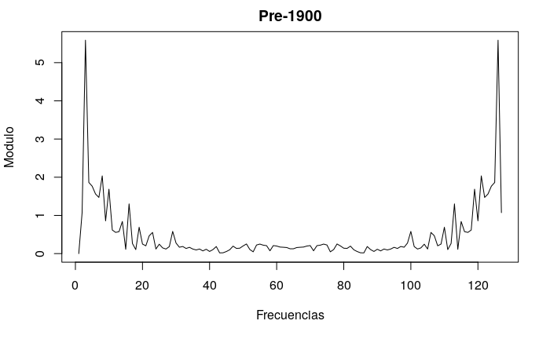

```r
cpi_log_cntr_pre = cpi$cpi_log[cpi$year <= 1900] - predict(cpi_log_lm_pre,
                                                           newdata = cpi[cpi$year <= 1900, "year"])
cpi_log_cntr_post = cpi$cpi_log[cpi$year > 1900] - predict(cpi_log_lm_post,
                                                           newdata = cpi[cpi$year > 1900, "year"])
fft_cpi_log_cntr_pre  = fft(cpi_log_cntr_pre)
fft_cpi_log_cntr_post = fft(cpi_log_cntr_post)
plot(Mod(fft_cpi_log_cntr_pre), type = "l", xlab = "Frecuencias", ylab = "Modulo", main = "Pre-1900")
```

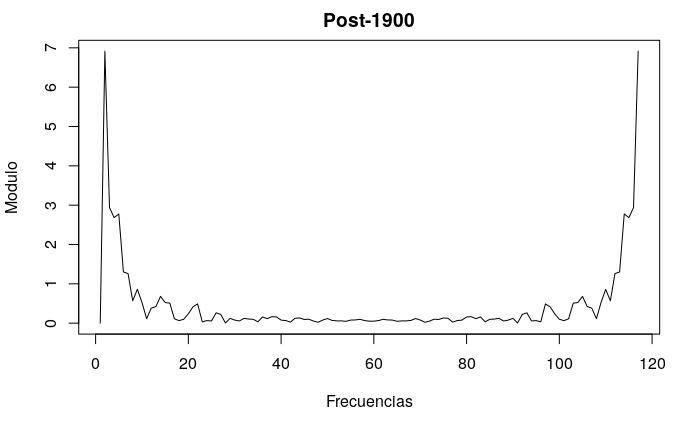

```r
plot(Mod(fft_cpi_log_cntr_post), type = "l", xlab = "Frecuencias", ylab = "Modulo", main = "Post-1900")
```

```r
cpi_antifft_10_pre = Re(
    fft(
      fft_cpi_log_cntr_pre * c(rep(1,10), rep(0, length(fft_cpi_log_cntr_pre) - 19), rep(1,9)),
      inverse = TRUE
    ) / length(fft_cpi_log_cntr_pre)
  )
cpi_antifft_10_post = Re(
    fft(
      fft_cpi_log_cntr_post * c(rep(1,10), rep(0, length(fft_cpi_log_cntr_post) - 19), rep(1,9)),
      inverse = TRUE
    ) / length(fft_cpi_log_cntr_post)
  )
plot(y=c(cpi_log_cntr_pre, cpi_log_cntr_post), x=cpi$year, type="l")
lines(y=c(cpi_antifft_10_pre, cpi_antifft_10_post), x=cpi$year, col="red")
```

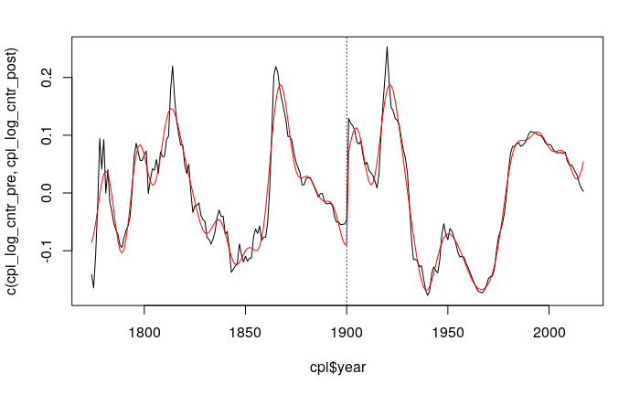

```r
abline(v=1900,col="blue",lty=3)
```

```r
cpi_rsq_antifft10 = 1 - (sum((na.omit(c(cpi_log_cntr_pre, cpi_log_cntr_post)) - c(cpi_antifft_10_pre, cpi_antifft_10_post)) ^ 2,
                          na.rm = TRUE) /
                          sum((na.omit(c(cpi_log_cntr_pre, cpi_log_cntr_post)) - mean(c(cpi_log_cntr_pre, cpi_log_cntr_post),
                                                                            na.rm = TRUE)) ^ 2,
                              na.rm = TRUE))
plot(
  x = cpi$year[cpi$year <= 1900],
  y = cpi_antifft_10_pre,
  type = "l", ylab = "CPI centrado", xlab = "Años", lwd = 2
)
lines(
  x = cpi$year[cpi$year <= 1900],
  y = Re(
    fft(
      fft_cpi_log_cntr_pre * c(rep(0,10), rep(1, length(fft_cpi_log_cntr_pre) - 19), rep(0,9)),
      inverse = TRUE
    ) / nrow(cpi)
  ),
  type = "l", col = "blue", lwd = 2
)
```

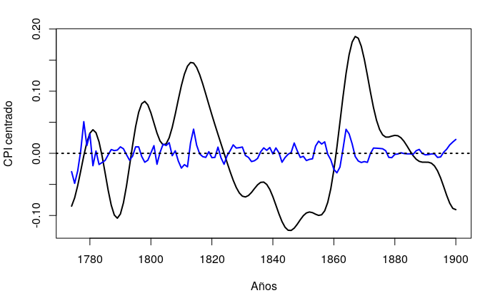

```r
abline(h = 0, lty = 3, lwd = 2)
```

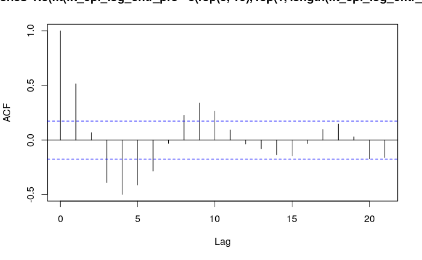

```r
acf(Re(
    fft(
      fft_cpi_log_cntr_pre * c(rep(0,10), rep(1, length(fft_cpi_log_cntr_pre) - 19), rep(0,9)),
      inverse = TRUE
    ) / length(fft_cpi_log_cntr_pre)
  ))
```

```r
# Con un filtro pasaaltos todavía queda estructura de corto plazo, pero tenemos una buena aproximación de las ondas de largo plazo.
```

Puede observarse que en los años en torno a 1971, año en que EE.UU. abandona definitivamente el patrón oro, la serie cambia completamente, por lo que habría que analizar la serie antes y después de esa fecha, ya que el índice de precios, bajo la teoría monetarista de la inflación, puede estar directamente ligada a la emisión de dinero, que desde 1971 puede darse sin respaldo en oro en los EE.UU.

Midiendo el R cuadrado que podemos obtener de estos componentes.

```
[1] 0.89518
[1] 0.9712226
```

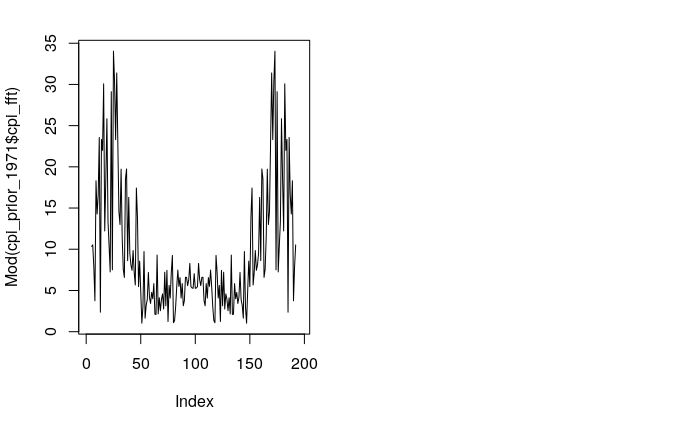

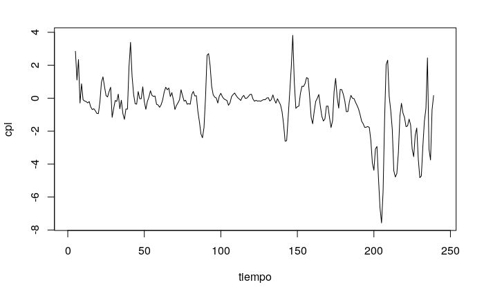

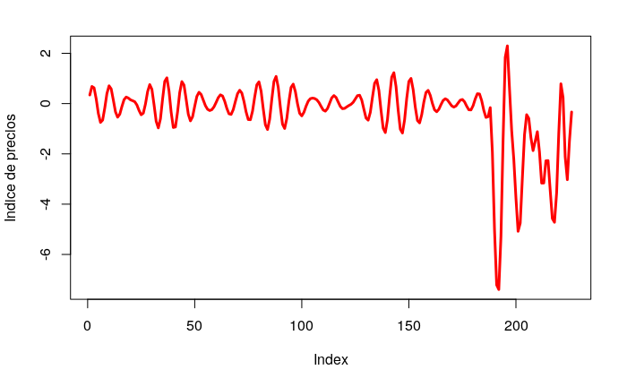

## Serie del pbi real

Por lo que se puede apreciar en la figura, el pbi no parece ser un proceso estacionario, puesto que la varianza crece al limpiar la tendencia central (centrar la serie) luego de aplicar una media movil centrada de orden 10.

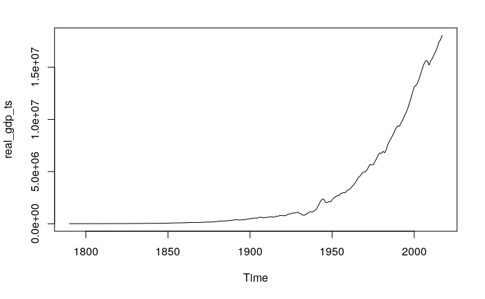

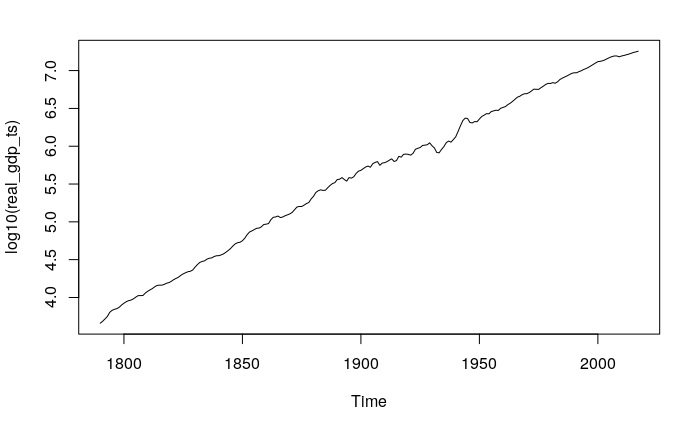

```
Call:
lm(formula = log10(real_gdp_ts) ~ gdp$year)

Residuals:
      Min        1Q    Median        3Q       Max
-0.170577 -0.051362 -0.003138  0.043200  0.159020

Coefficients:
              Estimate Std. Error t value Pr(>|t|)
(Intercept) -2.463e+01  1.367e-01  -180.2   <2e-16 ***
gdp$year     1.589e-02  7.177e-05   221.4   <2e-16 ***
---
Signif. codes:  0 ‘***’ 0.001 ‘**’ 0.01 ‘*’ 0.05 ‘.’ 0.1 ‘ ’ 1

Residual standard error: 0.07133 on 226 degrees of freedom
Multiple R-squared:  0.9954,    Adjusted R-squared:  0.9954
F-statistic: 4.902e+04 on 1 and 226 DF,  p-value: < 2.2e-16
```

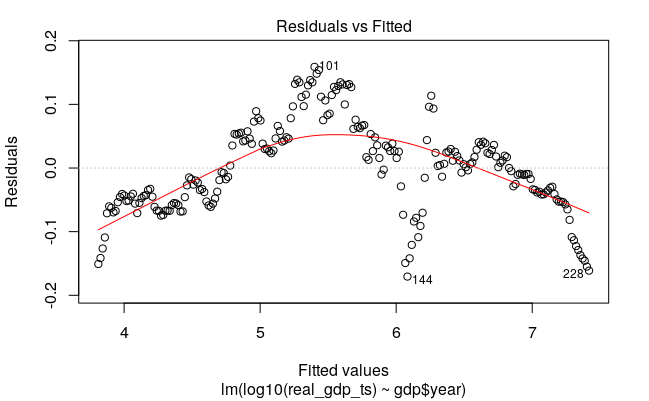

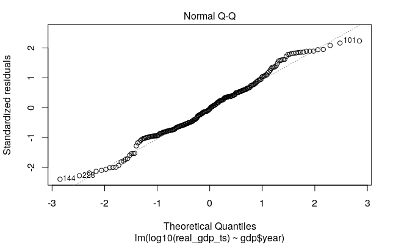

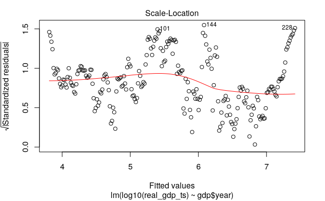

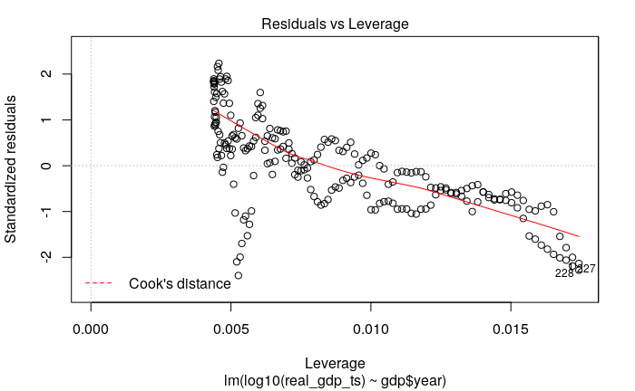

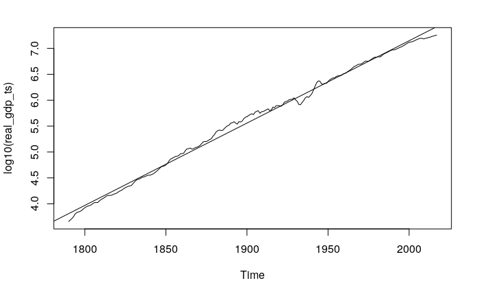

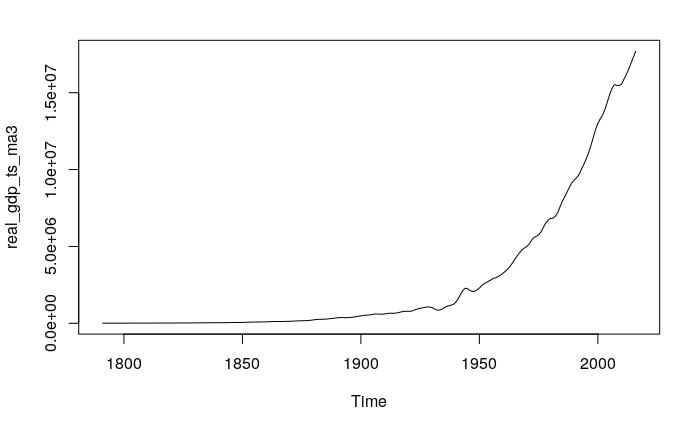

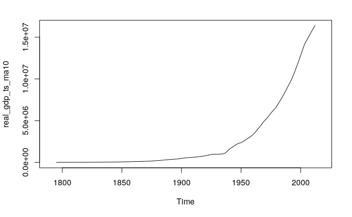

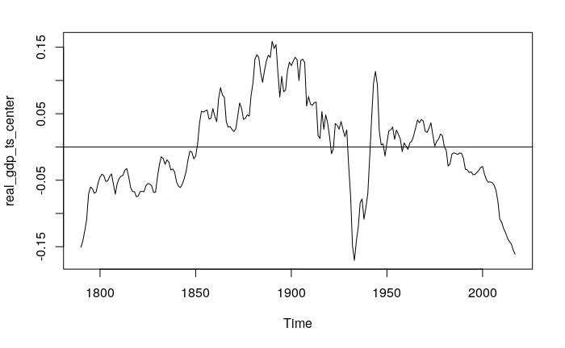

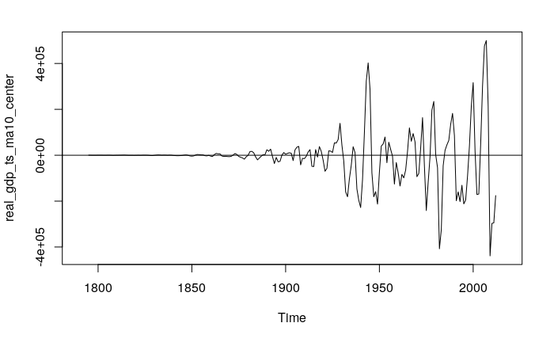

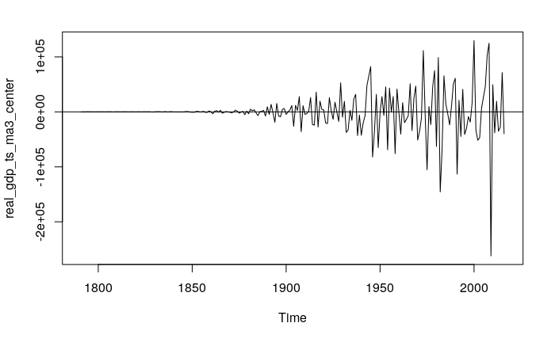

Una vez centrada la serie podemos buscar ciclos en la serie usando la transformada de Fourier.

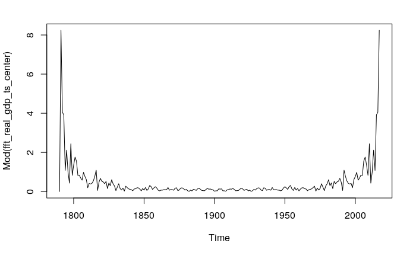

Descomponiendo la serie

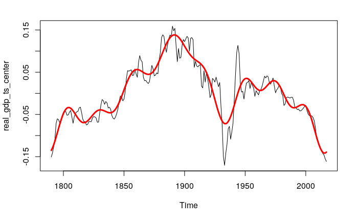

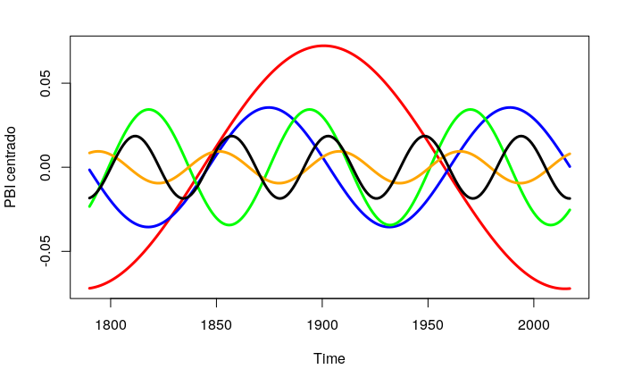

Revisando el histograma de esta serie de tiempo

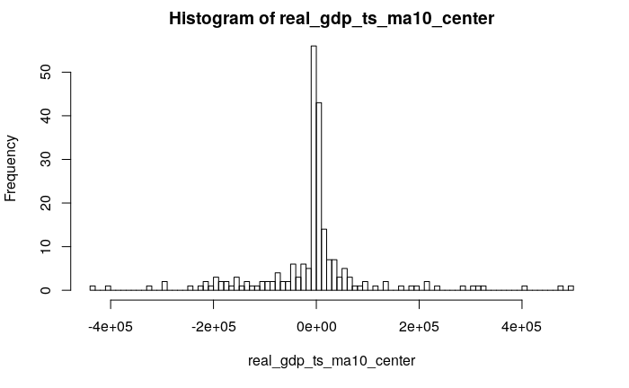

Su autocorrelacion: no parece ser puramente aleatoria

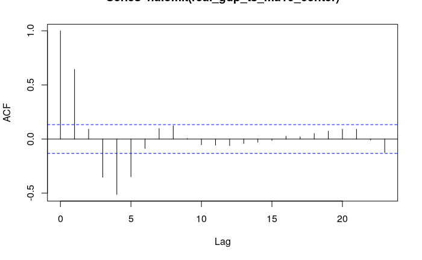

Aunque esta idea podria no ser cierta debida a la falta de estacionariedad.

```r
adf.test(na.omit(real_gdp_ts_ma10_center))
```

```
p-value smaller than printed p-value
```

```
    Augmented Dickey-Fuller Test

data:  na.omit(real_gdp_ts_ma10_center)
Dickey-Fuller = -6.7932, Lag order = 6, p-value = 0.01
alternative hypothesis: stationary
```

```r
kpss.test(na.omit(real_gdp_ts_ma10_center))
```

```
p-value greater than printed p-value
```

```
    KPSS Test for Level Stationarity

data:  na.omit(real_gdp_ts_ma10_center)
KPSS Level = 0.049771, Truncation lag parameter = 3, p-value = 0.1
```

Vemos a continuación lo que pasa con la tasa de crecimiento del PBI de los EE.UU. en lugar de su nivel absoluto, como en el apartado anterior.

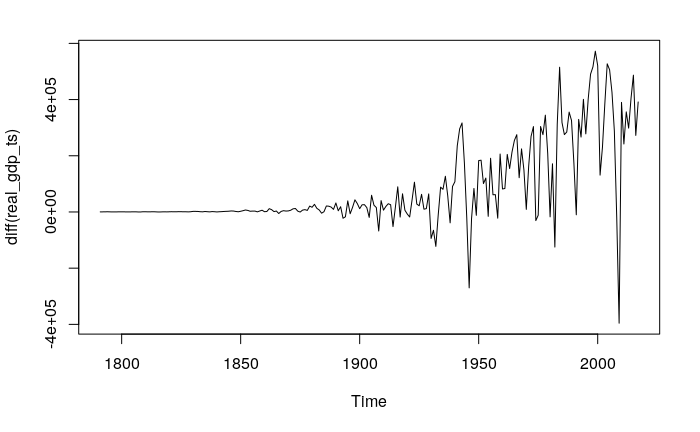

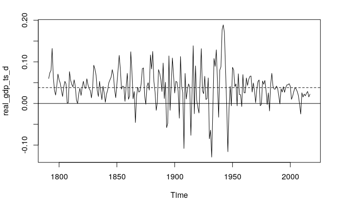

```
[1] 0.03808062
```

La media de crecimiento durante todo este periodo es del 3,8% con distinta varianza a lo largo de la serie.

Realizamos tests de estacionariedad.

```r
adf.test(real_gdp_ts_d)
```

```
p-value smaller than printed p-value
```

```
    Augmented Dickey-Fuller Test

data:  real_gdp_ts_d
Dickey-Fuller = -5.5602, Lag order = 6, p-value = 0.01
alternative hypothesis: stationary
```

```r
kpss.test(real_gdp_ts_d)
```

```
p-value greater than printed p-value
```

```
    KPSS Test for Level Stationarity

data:  real_gdp_ts_d
KPSS Level = 0.25208, Truncation lag parameter = 3, p-value = 0.1
```

Vemos ahora la transformada de Fourier para la serie.

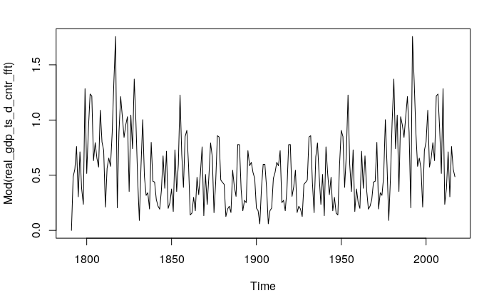

La transformada de Fourier no es conclusiva acerca de ciclos de Kondratieff en la economía de los EE.UU.. Lo que se puede observar es que la economía de los EE.UU. es altamente estable en cuanto a producto, experimentando solo ciclos de baja intensidad y aleatorios alrededor de una media marcada de crecimiento. En el largo plazo (considerando la cantidad de años que estamos tomando para este análisis) las grandes crisis económicos (décadas del ’30, ’70, principios de los 2000, 2008) quedan diluidas en una gran regresión a la media de tasa de crecimiento de los EE.UU.

## Tasas de interés de los EE.UU.

Ahondaremos aún más en la búsqueda de ondas de Kondratieff en la serie de los EE.UU.

[output not shown]

## Análisis de la serie del Dow Jones

El índice de Dow Jones es uno de los índices más seguidos en el mundo financiero ya que nuclea importantes empresas del mercado mundial.

La forma de construir el índice ha cambiado en el transcurso del tiempo, por lo que no se estan realmente observando las mismas empresas a lo largo de toda la serie.

A continuación intentamos realizar predicciones sobre el índice.

```r
dja_modelo = auto.arima(y = dja_ts)
plot(forecast(dja_modelo,h=10), include = c(80, 95))
```

[output not shown]